# Forecasting Earthquakes

**This data is from the National Earthquake Information Center [NEIC](https://www.kaggle.com/datasets/usgs/earthquake-database) which is the US archive for earthquake information. This forecast solely involves data from 1981 and 2016. *This closereading is meant for the general public***

# Section 1:Forecasting Earthquakes

It is commonly known that sismic activity is unpredictable and there is not enough current evidence to establish that earthquakes happen at a specific place, climate or time. We currently only predict their long-term occurence and the general area of sismic activity leaving us without much preparation for the eventually of a dangerous earthquake.

I will be attempting to forecast the magnitude and prevalence of these earthquakes in the US with data from the NEIC by modeling the shape and direction of the data.

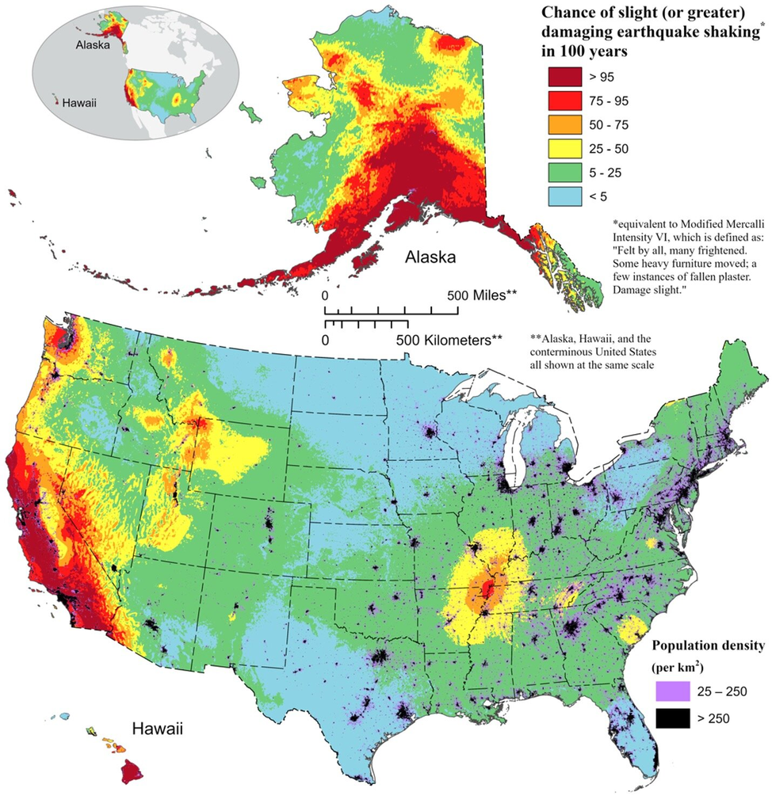

Mortality: Earthquakes kill around 360 people every year and injure thousands.

# Section 2: Earthquakes Across Time

According to the data, Earthquakes have been occurring pretty regularly since 1981, with a relatively stable monthly magnitude on average.

However, there seems to be no common knowledge and limited literature on the predictable trends or seasonal patterns of earthquakes. Such knowledge would help us take proactive measures to maximise safety and potentially decrease the US earthquake mortality int he future.

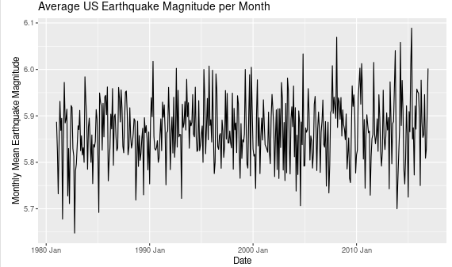

# Section 3: “Earthquake prevalence: Total monthly US Earthquakes from 1981 to 2016

The monthly occurence of US earthquakes is pretty stable as well, except for some irregularly large spikes in monthly earthquake count with:

83 in November of the year 2000, 110 earthquakes in December 2004 and 226 earthquakes in March 2011.

These peaks seem to be getting taller across the years so perhaps it isworth gathering more data to support or refute this overall trend.

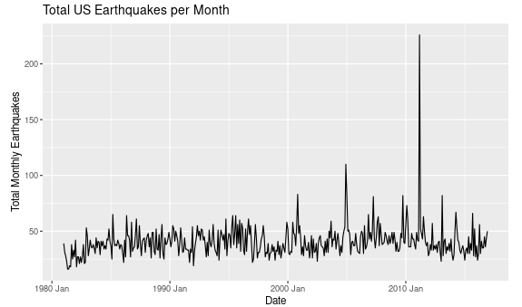

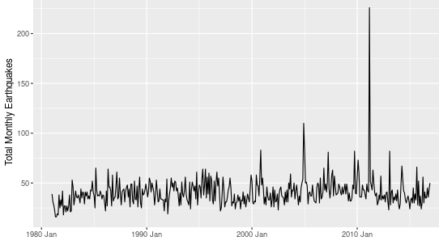

# Section 4: Is there such a thing as Earthquake season?

While we do not currently have evidence to establish that earthquakes happen in any specific place, time or conditions, recent research is exploring some potentially significant inrcreases in the magnitude and prevalence of earthquakes in areas of the Northern hemisphere like the US.

Our US data supports this notion with seasonal patterns shown in the subseries plot below, dsiplaying higher earthquake magnitudes in Spring months like April and May, as well as Autum months like October and November.

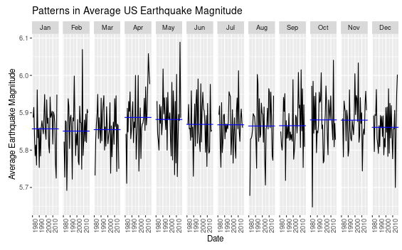

# Section 5: Forecast

[figure not shown]

### Sources:

[We can only predict where earthquakes are most likely to occur](https://www.usgs.gov/programs/earthquake-hazards/earthquake-facts-earthquake-fantasy#:~:text=FICTION:%20We%20can%20predict%20earthquakes,the%20region%20following%20large%20earthquakes.)

[We can predict earthquake long term occurrence](https://www.usgs.gov/programs/earthquake-hazards/earthquake-facts-earthquake-fantasy#:~:text=FICTION:%20We%20can%20predict%20earthquakes,the%20region%20following%20large%20earthquakes.)

[Earthquake Commentary for November, 2000](https://service.scedc.caltech.edu/ftp/ca.earthquakes/2000/November2000.html)

[Yellowstone Earthquake Swarm 2004](https://www.usgs.gov/observatories/yvo/news/2004-yellowstone-earthquake-swarm#:~:text=The%20swarm%20in%20April%202004,over%20the%20one%2Dmonth%20period.)

[The great Tohoku Earthquake impacted US seismic activity](https://www.conservation.ca.gov/cgs/tsunami/tohoku#:~:text=Damage%20Summary,Wilson%20et%20al.%2C%202013.)

[Initial image of sismic activity in the US](https://phys.org/news/2024-01-earthquakes.html)

[Earthquakes kill thousands](https://usafacts.org/articles/are-us-earthquakes-becoming-more-costly/#:~:text=The%20USGS%20and%20FEMA%20report,and%20360%20fatalities%20per%20year.)